# A Gentle Introduction to Statistics with R

Author

ZMT

## Learning objectives

After completing this session, you should be able to:

1. Know RStudio interface.
2. Run code interactively.
3. Run code from a script.
4. How to make comments in a script and understand why that is useful.
5. How to read a csv data into R and view it.
6. Know how to make basic plots.
7. Know the basic verbs of `dplyr`.
8. Know how to run some basic statistical tests in R: t.test, anova and linear regression.

## Data Analysis Model

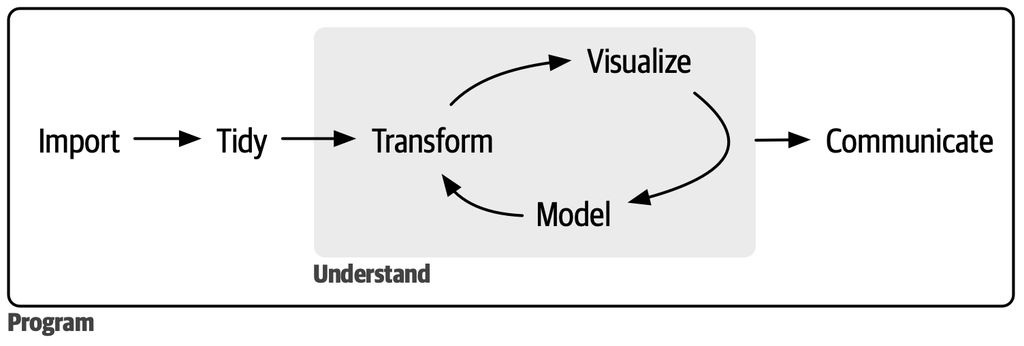

*Source: [R for Data Science](https://r4ds.hadley.nz/intro), second edition*

## Load packages

```r
library(tidyverse)
library(broom)
library(gtsummary)
```

## Read data

```r
dat <- read_csv("penguins.csv")
```

## View data

```r
# View(dat)
```

You can achieve the same thing by placing cursor on `dat` and press F2.

## Palmer Penguins Dataset

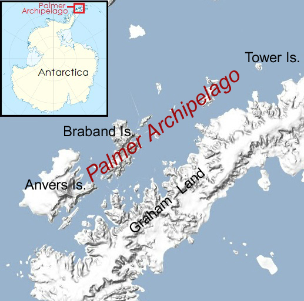

The [dataset](https://allisonhorst.github.io/palmerpenguins/) consists of 344 rows and 8 variables.

## Explore Data

Variable names.

```r
names(dat)
```

```
[1] "species"           "island"            "bill_length_mm"
[4] "bill_depth_mm"     "flipper_length_mm" "body_mass_g"
[7] "sex"               "year"
```

A glimpse at data.

```r
glimpse(dat)
```

```
Rows: 344
Columns: 8
$ species           <chr> "Adelie", "Adelie", "Adelie", "Adelie", "Adelie", "A…
$ island            <chr> "Torgersen", "Torgersen", "Torgersen", "Torgersen", …
$ bill_length_mm    <dbl> 39.1, 39.5, 40.3, NA, 36.7, 39.3, 38.9, 39.2, 34.1, …
$ bill_depth_mm     <dbl> 18.7, 17.4, 18.0, NA, 19.3, 20.6, 17.8, 19.6, 18.1, …
$ flipper_length_mm <dbl> 181, 186, 195, NA, 193, 190, 181, 195, 193, 190, 186…
$ body_mass_g       <dbl> 3750, 3800, 3250, NA, 3450, 3650, 3625, 4675, 3475, …
$ sex               <chr> "male", "female", "female", NA, "female", "male", "f…
$ year              <dbl> 2007, 2007, 2007, 2007, 2007, 2007, 2007, 2007, 2007…
```

Summary of variables.

```r
summary(dat)
```

```
   species             island          bill_length_mm  bill_depth_mm
 Length:344         Length:344         Min.   :32.10   Min.   :13.10
 Class :character   Class :character   1st Qu.:39.23   1st Qu.:15.60
 Mode  :character   Mode  :character   Median :44.45   Median :17.30
                                       Mean   :43.92   Mean   :17.15
                                       3rd Qu.:48.50   3rd Qu.:18.70
                                       Max.   :59.60   Max.   :21.50
                                       NA's   :2       NA's   :2
 flipper_length_mm  body_mass_g       sex                 year
 Min.   :172.0     Min.   :2700   Length:344         Min.   :2007
 1st Qu.:190.0     1st Qu.:3550   Class :character   1st Qu.:2007
 Median :197.0     Median :4050   Mode  :character   Median :2008
 Mean   :200.9     Mean   :4202                      Mean   :2008
 3rd Qu.:213.0     3rd Qu.:4750                      3rd Qu.:2009
 Max.   :231.0     Max.   :6300                      Max.   :2009
 NA's   :2         NA's   :2
```

Tabulate categorical variables.

```r
table(dat$species)
```

```
   Adelie Chinstrap    Gentoo
      152        68       124
```

```r
table(dat$island)
```

```
   Biscoe     Dream Torgersen
      168       124        52
```

Plot histogram.

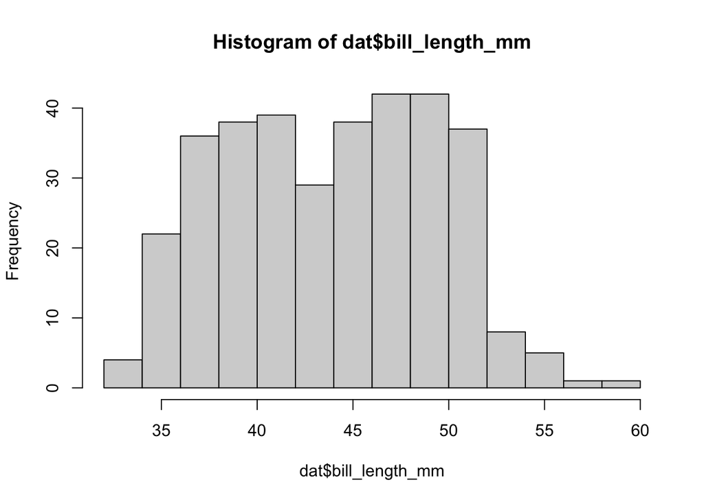

```r
hist(dat$bill_length_mm, breaks = 10)
```

Plot bar chart.

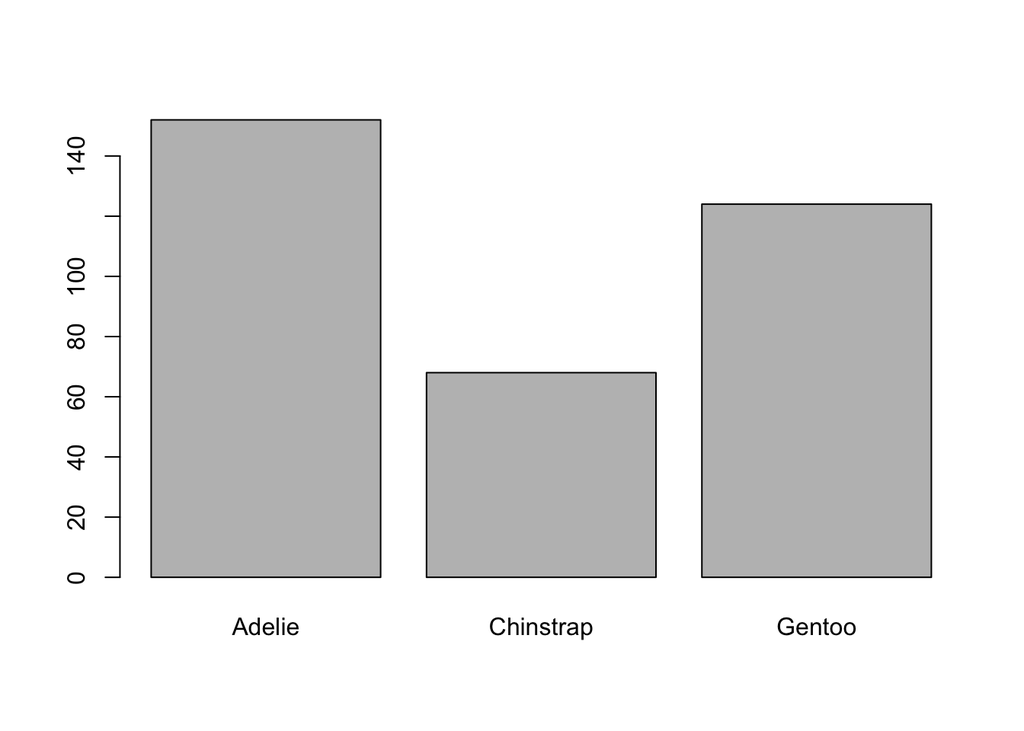

```r
barplot(table(dat$species))
```

Use pipe `|>`.

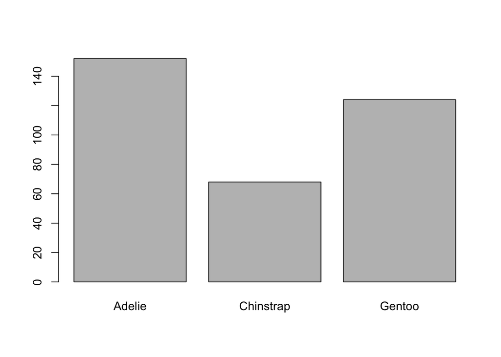

```r
dat$species |>
  table() |>
  barplot()
```

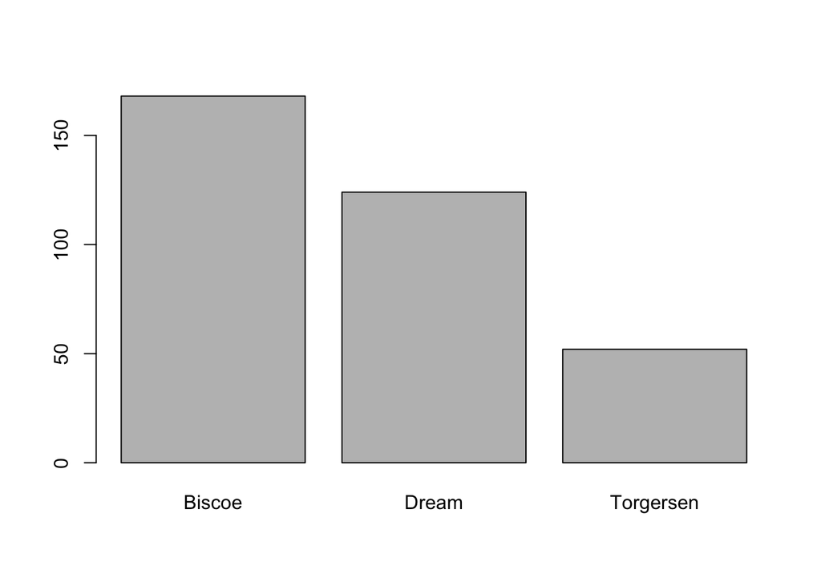

```r
dat$island |>
  table() |>
  barplot()
```

Make a pie chart.

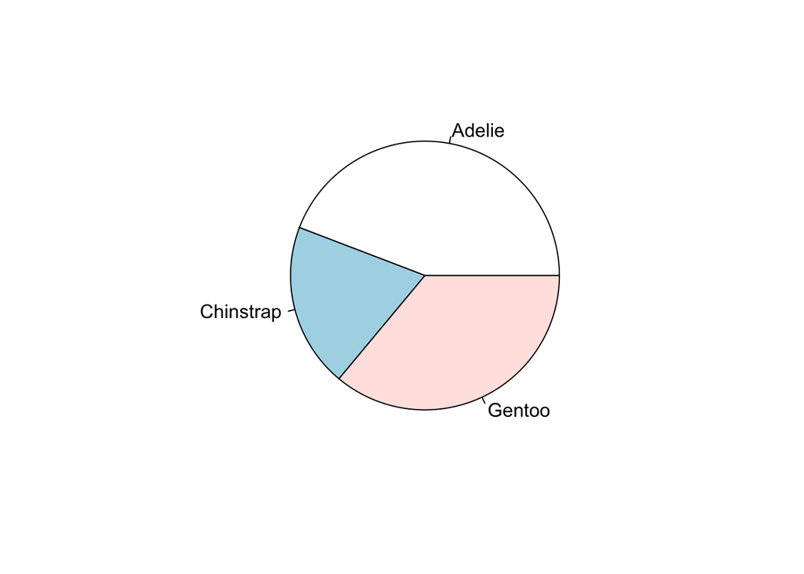

```r
dat$species |>
  table() |>
  pie()
```

## `dplyr` Basic Verbs for Data Management

- `select()`: subset columns
- `filter()`: subset rows on conditions
- `mutate()`: create new columns by using information from other columns
- `group_by()` and `summarize()`: create summary statistics on grouped data
- `arrange()`: sort results
- `count()`: count discrete values

### Select columns and filter rows

Select columns `species`, `island`, `year`.

```r
select(dat, species, island, year)
```

```
# A tibble: 344 × 3
   species island     year
   <chr>   <chr>     <dbl>
 1 Adelie  Torgersen  2007
 2 Adelie  Torgersen  2007
 3 Adelie  Torgersen  2007
 4 Adelie  Torgersen  2007
 5 Adelie  Torgersen  2007
 6 Adelie  Torgersen  2007
 7 Adelie  Torgersen  2007
 8 Adelie  Torgersen  2007
 9 Adelie  Torgersen  2007
10 Adelie  Torgersen  2007
# ℹ 334 more rows
```

```r
dat |> select(species, island, year)
```

```
# A tibble: 344 × 3
   species island     year
   <chr>   <chr>     <dbl>
 1 Adelie  Torgersen  2007
 2 Adelie  Torgersen  2007
 3 Adelie  Torgersen  2007
 4 Adelie  Torgersen  2007
 5 Adelie  Torgersen  2007
 6 Adelie  Torgersen  2007
 7 Adelie  Torgersen  2007
 8 Adelie  Torgersen  2007
 9 Adelie  Torgersen  2007
10 Adelie  Torgersen  2007
# ℹ 334 more rows
```

```r
dat |> select(flipper_length_mm, body_mass_g)
```

```
# A tibble: 344 × 2
   flipper_length_mm body_mass_g
               <dbl>       <dbl>
 1               181        3750
 2               186        3800
 3               195        3250
 4                NA          NA
 5               193        3450
 6               190        3650
 7               181        3625
 8               195        4675
 9               193        3475
10               190        4250
# ℹ 334 more rows
```

Select rows (observations) of the year 2008 onward.

```r
dat |> filter(year >= 2008)
```

```
# A tibble: 234 × 8
   species island bill_length_mm bill_depth_mm flipper_length_mm body_mass_g
   <chr>   <chr>           <dbl>         <dbl>             <dbl>       <dbl>
 1 Adelie  Biscoe           39.6          17.7               186        3500
 2 Adelie  Biscoe           40.1          18.9               188        4300
 3 Adelie  Biscoe           35            17.9               190        3450
 4 Adelie  Biscoe           42            19.5               200        4050
 5 Adelie  Biscoe           34.5          18.1               187        2900
 6 Adelie  Biscoe           41.4          18.6               191        3700
 7 Adelie  Biscoe           39            17.5               186        3550
 8 Adelie  Biscoe           40.6          18.8               193        3800
 9 Adelie  Biscoe           36.5          16.6               181        2850
10 Adelie  Biscoe           37.6          19.1               194        3750
# ℹ 224 more rows
# ℹ 2 more variables: sex <chr>, year <dbl>
```

**Challenge**

Using pipes, subset the data to include penguins data collected in 2007 and retain only numeric columns.

```r
dat |>
  filter(year == 2007) |>
  select(bill_length_mm, bill_depth_mm, flipper_length_mm, body_mass_g, year)
```

```
# A tibble: 110 × 5
   bill_length_mm bill_depth_mm flipper_length_mm body_mass_g  year
            <dbl>         <dbl>             <dbl>       <dbl> <dbl>
 1           39.1          18.7               181        3750  2007
 2           39.5          17.4               186        3800  2007
 3           40.3          18                 195        3250  2007
 4           NA            NA                  NA          NA  2007
 5           36.7          19.3               193        3450  2007
 6           39.3          20.6               190        3650  2007
 7           38.9          17.8               181        3625  2007
 8           39.2          19.6               195        4675  2007
 9           34.1          18.1               193        3475  2007
10           42            20.2               190        4250  2007
# ℹ 100 more rows
```

### Create new column

Create a new column of `bill_length_mm` in cm.

```r
dat1 <- dat |>
  mutate(bill_length_cm = bill_length_mm / 10)

glimpse(dat1)
```

```
Rows: 344
Columns: 9
$ species           <chr> "Adelie", "Adelie", "Adelie", "Adelie", "Adelie", "A…
$ island            <chr> "Torgersen", "Torgersen", "Torgersen", "Torgersen", …
$ bill_length_mm    <dbl> 39.1, 39.5, 40.3, NA, 36.7, 39.3, 38.9, 39.2, 34.1, …
$ bill_depth_mm     <dbl> 18.7, 17.4, 18.0, NA, 19.3, 20.6, 17.8, 19.6, 18.1, …
$ flipper_length_mm <dbl> 181, 186, 195, NA, 193, 190, 181, 195, 193, 190, 186…
$ body_mass_g       <dbl> 3750, 3800, 3250, NA, 3450, 3650, 3625, 4675, 3475, …
$ sex               <chr> "male", "female", "female", NA, "female", "male", "f…
$ year              <dbl> 2007, 2007, 2007, 2007, 2007, 2007, 2007, 2007, 2007…
$ bill_length_cm    <dbl> 3.91, 3.95, 4.03, NA, 3.67, 3.93, 3.89, 3.92, 3.41, …
```

### Aggregate

Get average bill length and depth by species.

```r
dat |>
  group_by(species) |>
  summarise(
    avg_bill_length_mm = mean(bill_length_mm, na.rm = TRUE),
    avg_bill_depth_mm = mean(bill_depth_mm, na.rm = TRUE)
  )
```

```
# A tibble: 3 × 3
  species   avg_bill_length_mm avg_bill_depth_mm
  <chr>                  <dbl>             <dbl>
1 Adelie                  38.8              18.3
2 Chinstrap               48.8              18.4
3 Gentoo                  47.5              15.0
```

**Challenge**

Get average flipper length by island.

```r
dat |>
  group_by(island) |>
  summarise(
    avg_flipper_length_mm = mean(flipper_length_mm, na.rm = TRUE)
  )
```

```
# A tibble: 3 × 2
  island    avg_flipper_length_mm
  <chr>                     <dbl>
1 Biscoe                     210.
2 Dream                      193.
3 Torgersen                  191.
```

### Counting

```r
dat |> count(island)
```

```
# A tibble: 3 × 2
  island        n
  <chr>     <int>
1 Biscoe      168
2 Dream       124
3 Torgersen    52
```

```r
dat |> count(species)
```

```
# A tibble: 3 × 2
  species       n
  <chr>     <int>
1 Adelie      152
2 Chinstrap    68
3 Gentoo      124
```

```r
dat |> count(year)
```

```
# A tibble: 3 × 2
   year     n
  <dbl> <int>
1  2007   110
2  2008   114
3  2009   120
```

## Summary

```r
tbl_summary(dat)
```

| **Characteristic** | **N = 344**<sup>1</sup> |
| --- | --- |
| species |  |
| Adelie | 152 (44%) |
| Chinstrap | 68 (20%) |
| Gentoo | 124 (36%) |
| island |  |
| Biscoe | 168 (49%) |
| Dream | 124 (36%) |
| Torgersen | 52 (15%) |
| bill_length_mm | 44.5 (39.2, 48.5) |
| Unknown | 2 |
| bill_depth_mm | 17.30 (15.60, 18.70) |
| Unknown | 2 |
| flipper_length_mm | 197 (190, 213) |
| Unknown | 2 |
| body_mass_g | 4,050 (3,550, 4,750) |
| Unknown | 2 |
| sex |  |
| female | 165 (50%) |
| male | 168 (50%) |
| Unknown | 11 |
| year |  |
| 2007 | 110 (32%) |
| 2008 | 114 (33%) |
| 2009 | 120 (35%) |

<sup>1</sup> n (%); Median (IQR)

## Statistical tests

Q1. Is the flipper length different between male and female?

```r
dat |> count(sex)
```

```
# A tibble: 3 × 2
  sex        n
  <chr>  <int>
1 female   165
2 male     168
3 <NA>      11
```

```r
dat |> nrow()
```

```
[1] 344
```

```r
# Remove missing data first
dat_sex <- dat |> drop_na(sex)
dat |> count(sex)
```

```
# A tibble: 3 × 2
  sex        n
  <chr>  <int>
1 female   165
2 male     168
3 <NA>      11
```

```r
dat |> nrow()
```

```
[1] 344
```

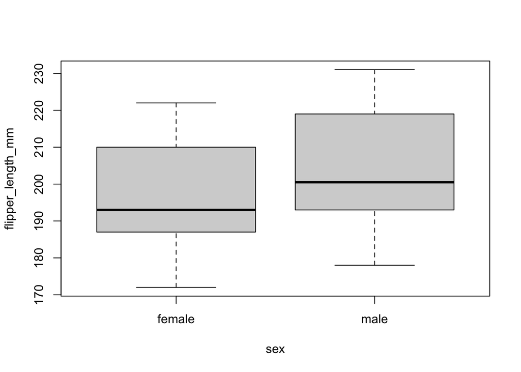

```r
boxplot(flipper_length_mm ~ sex, data = dat_sex)
```

```r
t.test(flipper_length_mm ~ sex, data = dat_sex)
```

```
    Welch Two Sample t-test

data:  flipper_length_mm by sex
t = -4.8079, df = 325.28, p-value = 2.336e-06
alternative hypothesis: true difference in means between group female and group male is not equal to 0
95 percent confidence interval:
 -10.064811  -4.219821
sample estimates:
mean in group female   mean in group male
            197.3636             204.5060
```

```r
t.test(flipper_length_mm ~ sex, data = dat_sex) |> tidy()
```

```
# A tibble: 1 × 10
  estimate estimate1 estimate2 statistic    p.value parameter conf.low conf.high
     <dbl>     <dbl>     <dbl>     <dbl>      <dbl>     <dbl>    <dbl>     <dbl>
1    -7.14      197.      205.     -4.81 0.00000234      325.    -10.1     -4.22
# ℹ 2 more variables: method <chr>, alternative <chr>
```

Q2. Is the bill length different by species?

```r
dat |> count(species)
```

```
# A tibble: 3 × 2
  species       n
  <chr>     <int>
1 Adelie      152
2 Chinstrap    68
3 Gentoo      124
```

```r
dat |> nrow()
```

```
[1] 344
```

```r
dat_bill <- dat |> drop_na(bill_length_mm)
dat_bill |> count(species)
```

```
# A tibble: 3 × 2
  species       n
  <chr>     <int>
1 Adelie      151
2 Chinstrap    68
3 Gentoo      123
```

```r
dat |> nrow()
```

```
[1] 344
```

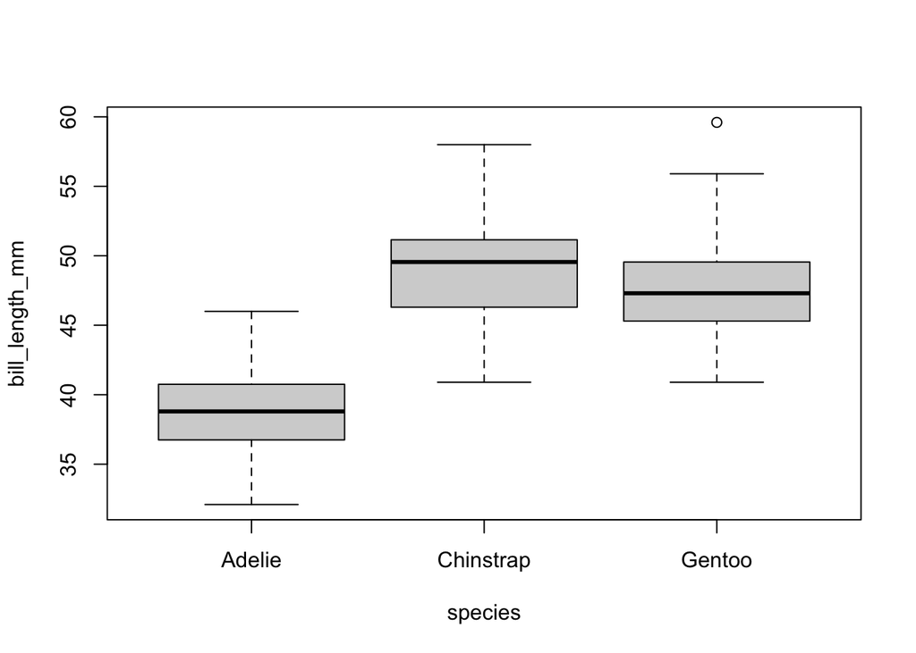

```r
boxplot(bill_length_mm ~ species, data = dat_bill)
```

```r
bill_anova <- aov(bill_length_mm ~ species, data = dat_bill)
bill_anova
```

```
Call:
   aov(formula = bill_length_mm ~ species, data = dat_bill)

Terms:
                 species Residuals
Sum of Squares  7194.317  2969.888
Deg. of Freedom        2       339

Residual standard error: 2.959853
Estimated effects may be unbalanced
```

```r
summary(bill_anova)
```

```
             Df Sum Sq Mean Sq F value Pr(>F)
species       2   7194    3597   410.6 <2e-16 ***
Residuals   339   2970       9
---
Signif. codes:  0 '***' 0.001 '**' 0.01 '*' 0.05 '.' 0.1 ' ' 1
```

```r
aov(bill_length_mm ~ species, data = dat_bill) |> tidy()
```

```
# A tibble: 2 × 6
  term         df sumsq  meansq statistic   p.value
  <chr>     <dbl> <dbl>   <dbl>     <dbl>     <dbl>
1 species       2 7194. 3597.        411.  2.69e-91
2 Residuals   339 2970.    8.76       NA  NA
```

Q3. Is bill length correlated with flipper length?

```r
dat |> nrow()
```

```
[1] 344
```

```r
dat_cor <- dat |>
  select(bill_length_mm, flipper_length_mm) |>
  drop_na()
dat_cor |> nrow()
```

```
[1] 342
```

```r
plot(dat_cor)

m <- lm(flipper_length_mm ~ bill_length_mm, data = dat_cor)
summary(m)
```

[output not shown]

```
Call:
lm(formula = flipper_length_mm ~ bill_length_mm, data = dat_cor)

Residuals:
    Min      1Q  Median      3Q     Max
-43.708  -7.896   0.664   8.650  21.179

Coefficients:
               Estimate Std. Error t value Pr(>|t|)
(Intercept)    126.6844     4.6651   27.16   <2e-16 ***
bill_length_mm   1.6901     0.1054   16.03   <2e-16 ***
---
Signif. codes:  0 '***' 0.001 '**' 0.01 '*' 0.05 '.' 0.1 ' ' 1

Residual standard error: 10.63 on 340 degrees of freedom
Multiple R-squared:  0.4306,    Adjusted R-squared:  0.4289
F-statistic: 257.1 on 1 and 340 DF,  p-value: < 2.2e-16
```

```r
est <- tidy(m)
est
```

```
# A tibble: 2 × 5
  term           estimate std.error statistic  p.value
  <chr>             <dbl>     <dbl>     <dbl>    <dbl>
1 (Intercept)      127.       4.67       27.2 3.65e-87
2 bill_length_mm     1.69     0.105      16.0 1.74e-43
```

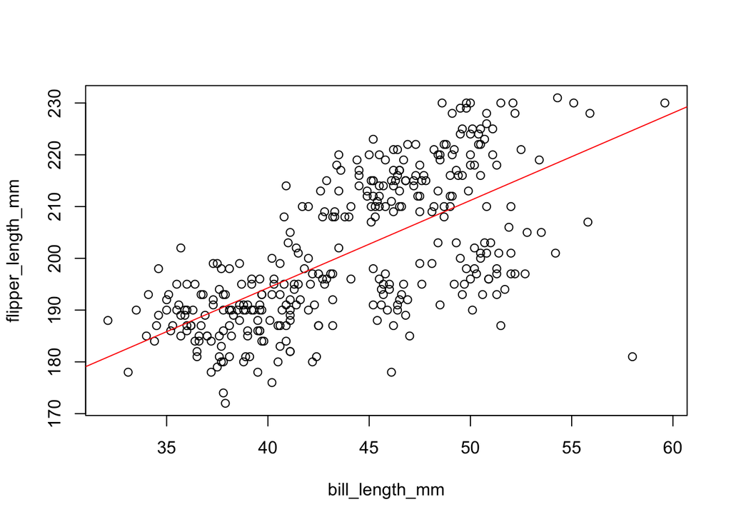

```r
plot(dat_cor)
abline(m, col = "red")
```